## ΒΝΠ 57 - Πρωτεομική, Γενωμική και Γονιδιοματική - 2η Γραπτή Εργασία

### Κωνσταντίνος Περπερίδης

- Εγκατάσταση επιπλέον βιβλιοθηκών

```r
install.packages("maptools", repos = "https://packagemanager.posit.co/cran/2023-10-13")
install.packages("UpSetR", repos = "http://cran.us.r-project.org")
```

- Φόρτιση βιβλιοθηκών

```r
library(GEOquery)
library(limma)
```

```r
library(umap)
library(maptools)
library(UpSetR)
library(tidyverse)
library(dplyr)
```

- Φόρτιση συνόλου δεδομένων (GEO2R)

```r
gset <- getGEO("GSE26125", GSEMatrix =TRUE, AnnotGPL=FALSE)
```

```
## Found 1 file(s)
```

```
## GSE26125_series_matrix.txt.gz
```

```r
if (length(gset) > 1) idx <- grep("GPL11329", attr(gset, "names")) else idx <- 1
gset <- gset[[idx]]
```

- Αλλαγή ονομάτων στηλών για συμβατότητα με εργαλεία ανάλυσης (GEO2R)

```r
fvarLabels(gset) <- make.names(fvarLabels(gset))
```

- Απόδοση μεταβλητής για διαχωρισμό των ομάδων (GEO2R)

```r
gsms <- "111111111111111100000"
sml <- strsplit(gsms, split="")[[1]]
```

- Μεταμόρφωση τιμών σε λογαριθμική κλίμακα (GEO2R)

```r
ex <- exprs(gset)
qx <- as.numeric(quantile(ex, c(0., 0.25, 0.5, 0.75, 0.99, 1.0), na.rm=T))
LogC <- (qx[5] > 100) ||
  (qx[6]-qx[1] > 50 && qx[2] > 0)
if (LogC) { ex[which(ex <= 0)] <- NaN
exprs(gset) <- log2(ex) }
```

- Κανονικοποίηση τιμών έκφρασης (GEO2R)

```r
exprs(gset) <- normalizeBetweenArrays(exprs(gset))
```

- Αντιστοίχιση δειγμάτων σε ομάδες και δημιουργία μήτρας σχεδίου (GEO2R)

```r
gs <- factor(sml)
groups <- make.names(c("control","disease"))
levels(gs) <- groups
gset$group <- gs
design <- model.matrix(~group + 0, gset)
colnames(design) <- levels(gs)
```

- Παράλειψη κενών τιμών (GEO2R)

```r
gset <- gset[complete.cases(exprs(gset)), ]
```

- Προσαρμογή δεδομένων σε γραμμικό μοντέλο για ανάλυση μέσω limma (GEO2R)

```r
fit <- lmFit(gset, design)
```

- Επανυπολογισμός συντελεστών μοντέλου (GEO2R)

```r
cts <- paste(groups[1], groups[2], sep="-")
cont.matrix <- makeContrasts(contrasts=cts, levels=design)
fit2 <- contrasts.fit(fit, cont.matrix)
```

- Στατιστική ανάλυση (GEO2R)

```r
fit2 <- eBayes(fit2, 0.01)
tT <- topTable(fit2, adjust="fdr", sort.by="B", number=250)

tT <- subset(tT, select=c("ID","adj.P.Val","P.Value","t","B","logFC","GeneName","GB_LIST","Gene_Symbol","SPOT_ID"))
write.table(tT, file=stdout(), row.names=F, sep="\t")
```

```
## "ID" "adj.P.Val" "P.Value"   "t" "B" "logFC" "GeneName"  "GB_LIST"   "Gene_Symbol"   "SPOT_ID"
## 42914    5.27892791330338e-06    1.9345235683463e-10 -10.2967933856558   13.626514273337 -4.07777785776253   "GE60494"   "NM_006003" "UQCRFS1"   ""
## 48667    1.31907721899213e-05    1.20989549034756e-09    -9.39148578956805   11.9674175337823    -2.8166160997362    "GE564959"  "NM_022745" "ATPAF1"    ""
## 46626    1.31907721899213e-05    1.91799212254183e-09    -9.17172472202536   11.5463866153392    -3.90418275693182   "GE82206"   "NM_017691" "LRRC49"    ""
## 40489    1.31907721899213e-05    2.07086002660195e-09    -9.13543594457119   11.4761637445782    -3.80380343624758   "GE57563"   "NM_003374" "VDAC1" ""
## 35751    1.31907721899213e-05    2.41695474016442e-09    -9.06254834877189   11.3345174673755    -3.86494385084827   "GE87653"   "CB998335"  ""  ""
## 40946    1.69365008747663e-05    3.72394478336989e-09    -8.86039196878309   10.9374479000898    -3.5259219468422    "GE62747"   "NM_003850" "SUCLA2"    ""
## 37386    1.96111356724429e-05    5.03070762632293e-09    -8.72119346739281   10.6604303010149    -3.00860451722541   "GE60478"   "NM_000019" "ACAT1" ""
## 36676    2.57525355271846e-05    7.64101511800322e-09    -8.52969643396991   10.2745112295286    -3.0983182330863    "GE57592"   "H66382"    ""  ""
## 51720    2.57525355271846e-05    8.49358031899228e-09    -8.48158238750883   10.1766692229284    -4.04817721853613   "GE80807"   "NM_152451" ""  ""
## 48369    3.61454965238602e-05    1.32459310040531e-08    -8.28096439953346   9.76489833714171    -4.65118477873277   "GE79053"   "NM_021914 NM_138638"   "CFL2"  ""
## 53140    4.01712076033586e-05    1.6585407456907e-08 -8.18037172573266   9.55612167386621    -3.36125401263807   "GE88245"   "R23839"    ""  ""
## 38025    4.01712076033586e-05    1.88167469734971e-08    -8.12415993195429   9.43878536609958    -2.32939240689145   "GE60231"   "NM_000688 NM_199166"   "ALAS1" ""
## 48539    4.01712076033586e-05    1.91375585914564e-08    -8.11664549827657   9.42306336570222    -3.15462900385442   "GE82670"   "NM_022163" "MRPL46"    ""
## 35426    5.17064996293043e-05    2.75960584290214e-08    -7.95476100581629   9.08228172953143    -3.05682101293706   "GE901957"  "CB143619"  ""  ""
```

[output cut: 236 more lines]

- Οπτικοποίηση ελέγχου ποιότητας της στατιστικής ανάλυσης (GEO2R)

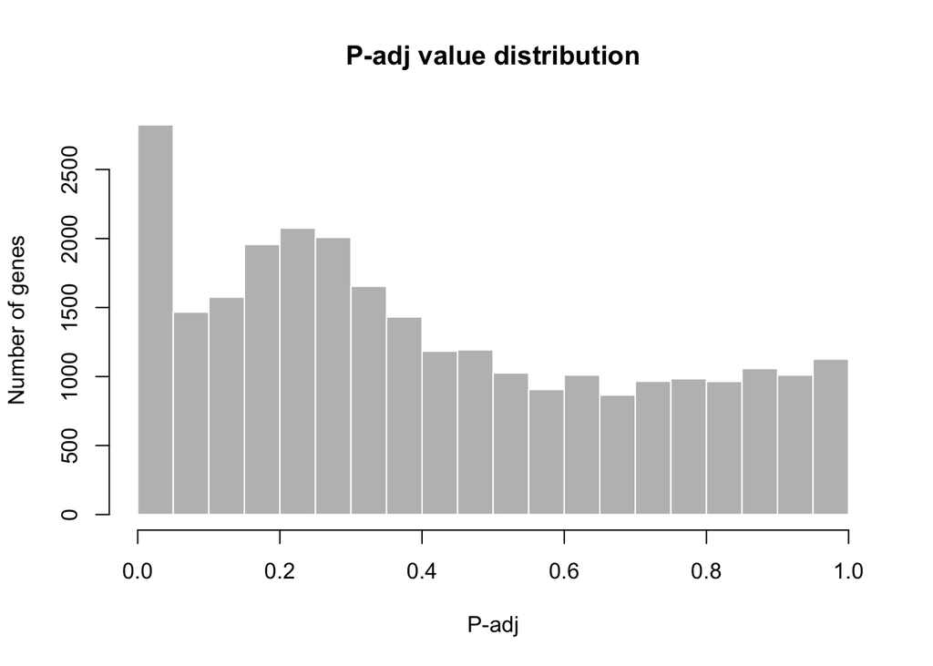

```r
tT2 <- topTable(fit2, adjust="fdr", sort.by="B", number=Inf)
hist(tT2$adj.P.Val, col = "grey", border = "white", xlab = "P-adj",
     ylab = "Number of genes", main = "P-adj value distribution")
```

```r
tT2_df <- as.data.frame(tT2)
View(tT2_df)

tT2_df_diffexp <- tT2_df[(tT2_df$logFC >= 1 | tT2_df$logFC <= -1) & tT2_df$adj.P.Val <= 0.05, ]
tT2_df_over <- tT2_df_diffexp[tT2_df_diffexp$logFC >= 1, ]
View(tT2_df_over)
```

- Διαχωρισμός υπερ- και υπο-εκφραζόμενων γονιδίων και καταγραφή σε αρχεία για ανάλυση εμπλουτισμού

```r
overexpressed_genes <- as.vector(tT2_df_over[tT2_df_over$Gene_Symbol != '',]$Gene_Symbol)
overexpressed_genes <- append(overexpressed_genes, tT2_df_over[tT2_df_over$Name != '',]$Name)
overexpressed_genes <- unique(overexpressed_genes)

View(overexpressed_genes)

tT2_df_under <- tT2_df_diffexp[tT2_df_diffexp$logFC <= -1, ]
underexpressed_genes <- as.vector(tT2_df_under[tT2_df_under$Gene_Symbol != '',]$Gene_Symbol)
underexpressed_genes <- append(underexpressed_genes, tT2_df_under[tT2_df_over$Name != '',]$Name)
underexpressed_genes <- unique(underexpressed_genes)

fo<-file("upregulated.txt")
writeLines(overexpressed_genes, fo)

fu<-file("underregulated.txt")
writeLines(underexpressed_genes, fu)
```

- Περίληψη αποτελεσμάτων σύμφωνα με αποτελέσματα στατιστικής ανάλυσης (GEO2R)

```r
dT <- decideTests(fit2, adjust.method="fdr", p.value=0.05, lfc=1)
dT_df <- as.data.frame(dT)
View(fit2)
summary(dT)
```

```
##        control-disease
## Down              2239
## NotSig           24486
## Up                 563
```

- Οπτικοποίηση αποτελεμάτων σε μορφή διαγράμματος Venn (GEO2R)

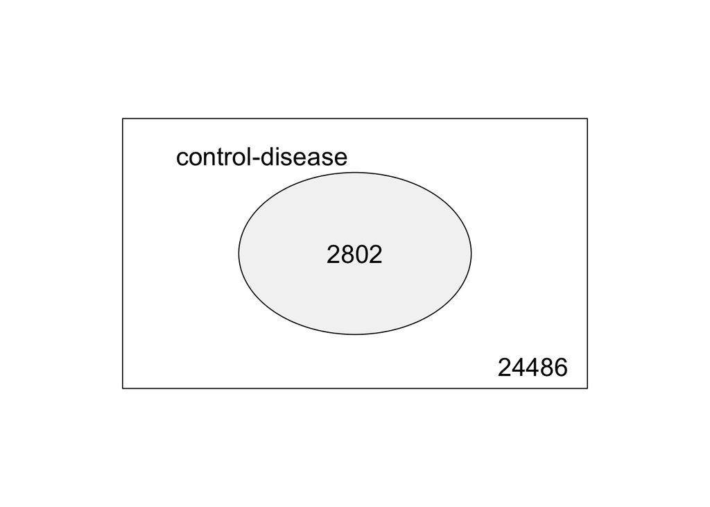

```r
vennDiagram(dT, circle.col=palette())
```

- Οπτικοποίηση αποτελέσματος t-test σε Quantile-Quantile Plot (GEO2R)

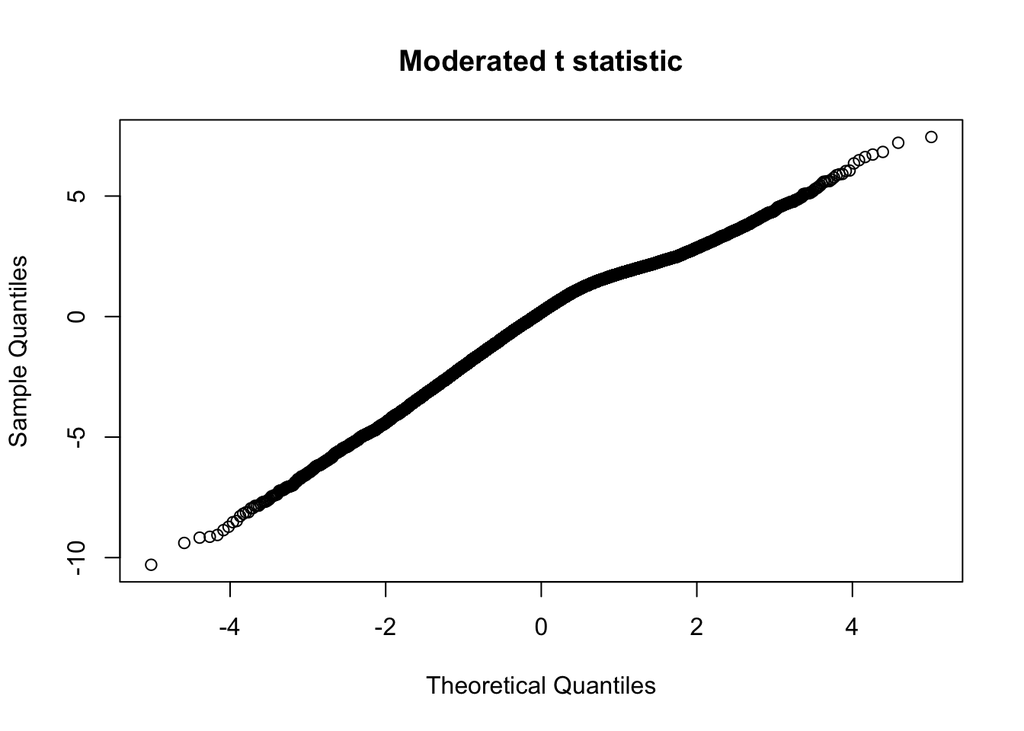

```r
t.good <- which(!is.na(fit2$F)) # filter out bad probes
qqt(fit2$t[t.good], fit2$df.total[t.good], main="Moderated t statistic")
```

- Οπτικοποίηση σε διάγραμμα σκέδασης (Volcano-Plot) (GEO2R)

```r
colnames(fit2)
```

```
## [1] "control-disease"
```

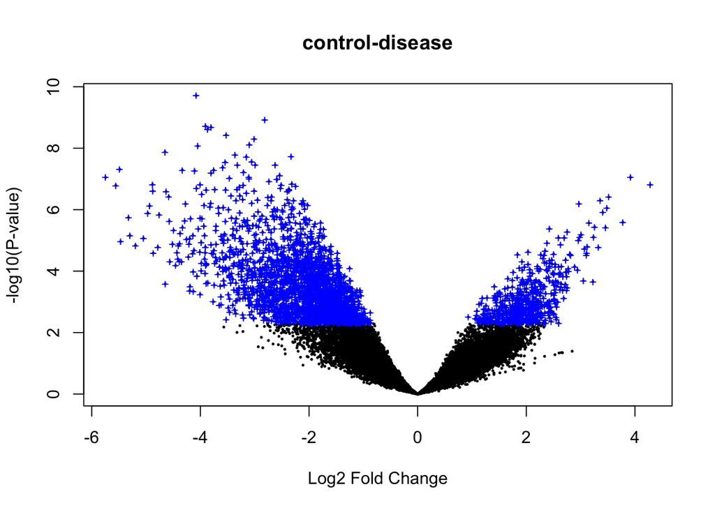

```r
ct <- 1
volcanoplot(fit2, coef=ct, main=colnames(fit2)[ct], pch=20,
            highlight=length(which(dT[,ct]!=0)), names=rep('+', nrow(fit2)))
```

- Οπτικοποίηση μέσων τιμών έκφρασης μέσω MD-Plot (GEO2R)

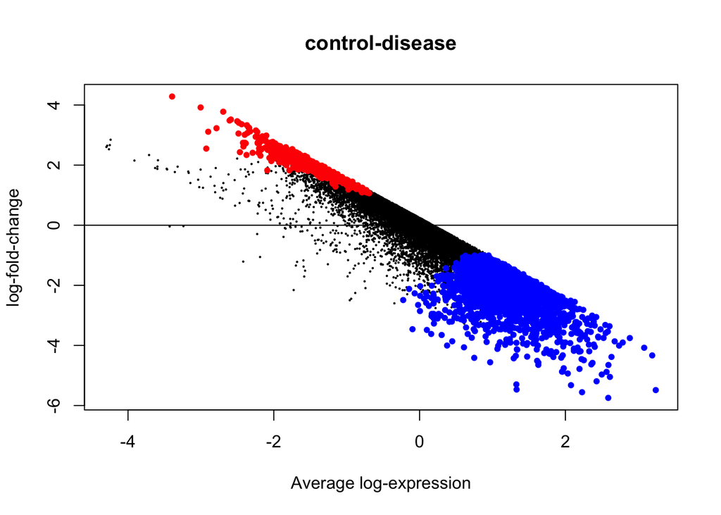

```r
plotMD(fit2, column=ct, status=dT[,ct], legend=F, pch=20, cex=1)
abline(h=0)
```

- Γενική ανάλυση δεδομένων (GEO2R)

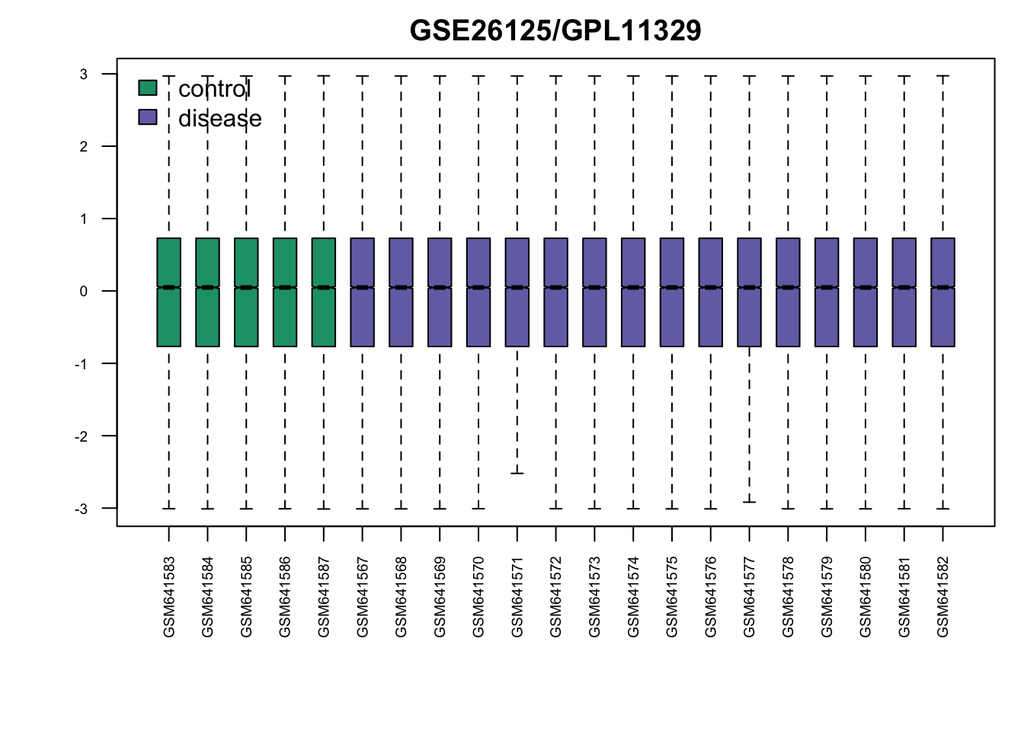

```r
ex <- exprs(gset)
ord <- order(gs)  # order samples by group
palette(c("#1B9E77", "#7570B3", "#E7298A", "#E6AB02", "#D95F02",
          "#66A61E", "#A6761D", "#B32424", "#B324B3", "#666666"))
par(mar=c(7,4,2,1))
title <- paste ("GSE26125", "/", annotation(gset), sep ="")
boxplot(ex[,ord], boxwex=0.6, notch=T, main=title, outline=FALSE, las=2, col=gs[ord], cex.axis=0.6)
legend("topleft", groups, fill=palette(), bty="n")
```

- Κατανομή τιμών έκφρασης (GEO2R)

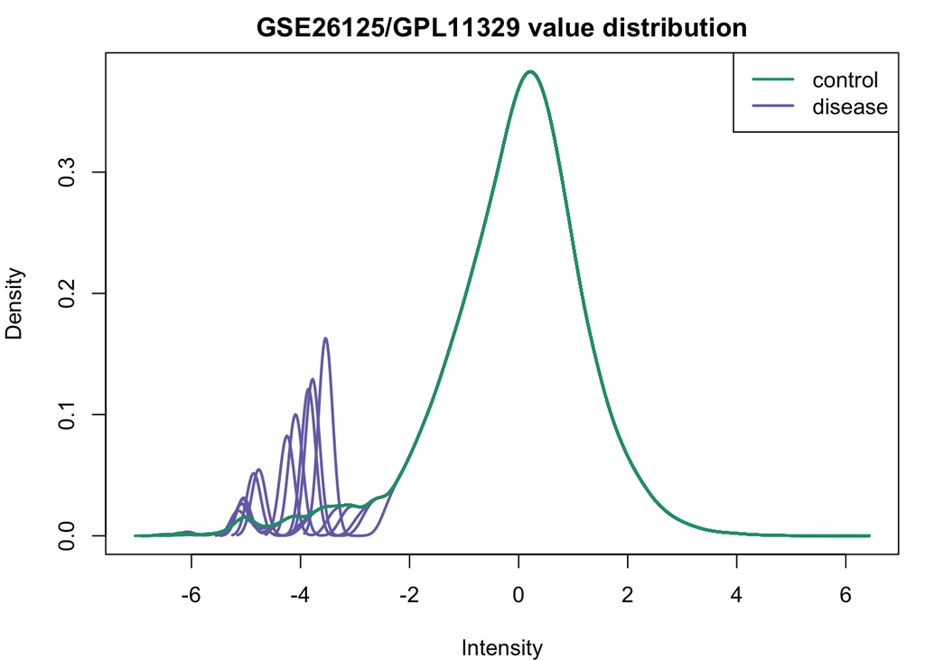

```r
par(mar=c(4,4,2,1))
title <- paste ("GSE26125", "/", annotation(gset), " value distribution", sep ="")
plotDensities(ex, group=gs, main=title, legend ="topright")
```

- Μείωση διαστάσεων δεδομένων μέσω UMAP (GEO2R)

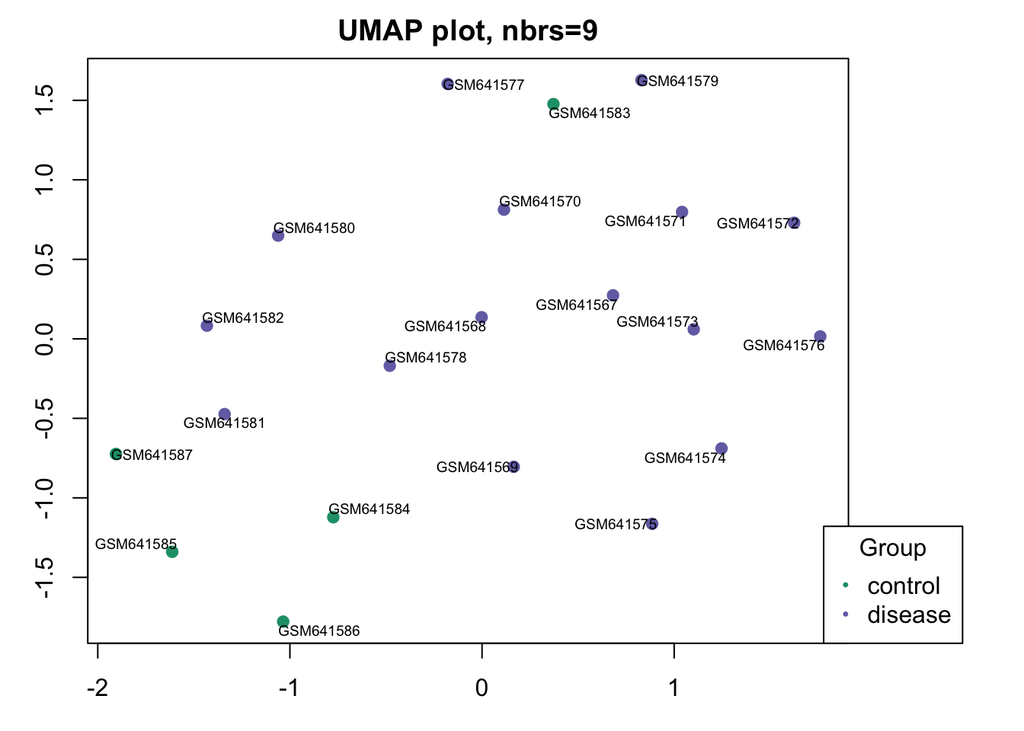

```r
ex <- na.omit(ex) # eliminate rows with NAs
ex <- ex[!duplicated(ex), ]  # remove duplicates
ump <- umap(t(ex), n_neighbors = 9, random_state = 123)
par(mar=c(3,3,2,6), xpd=TRUE)
plot(ump$layout, main="UMAP plot, nbrs=9", xlab="", ylab="", col=gs, pch=20, cex=1.5)
legend("bottomright", inset=c(-0.15,0), legend=levels(gs), pch=20,
       col=1:nlevels(gs), title="Group", pt.cex=0.5)
pointLabel(ump$layout, labels = rownames(ump$layout), method="SANN", cex=0.6)
```

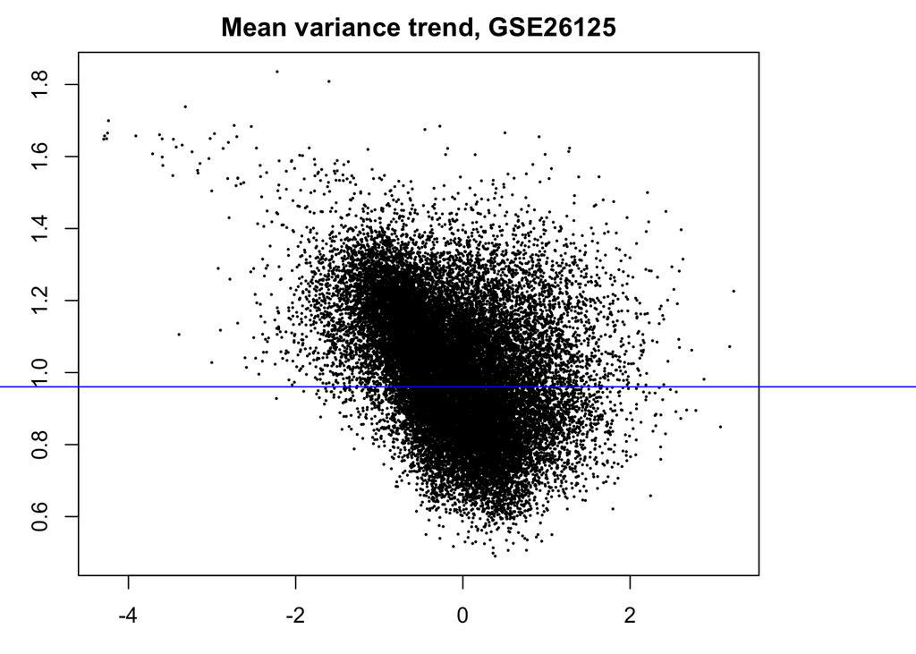

```r
plotSA(fit2, main="Mean variance trend, GSE26125")
```

- Εισαγωγή των δεδομένων ανάλυσης εμπλουτισμού και οπτικοποίηση αποτελεσμάτων

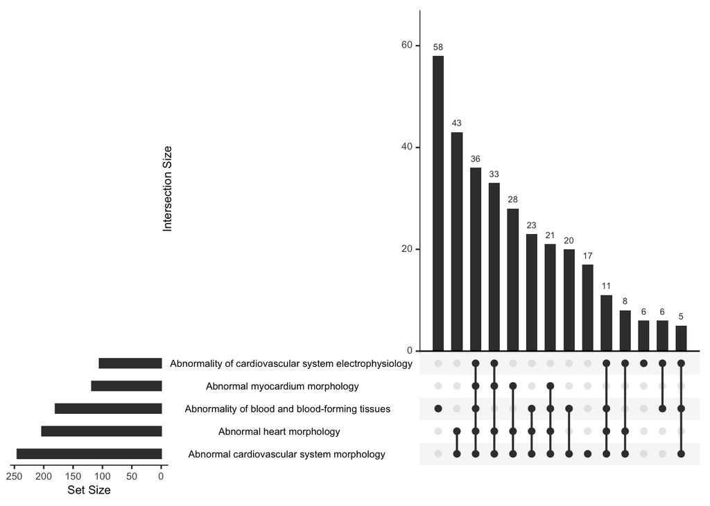

```r
library(dplyr)
library(tidyverse)
library(UpSetR)
enriched_down <- list.files(path = "./", pattern="*underexpressed*") %>% map_df(~read_tsv(.) %>% mutate(annotation_id = as.character(annotation_id)))
enriched_down_stat_sign <- enriched_down[enriched_down$pval_adj < 0.05, ]
enriched_down_cat_filter <- dplyr::filter(enriched_down_stat_sign, grepl("heart|vessel|tissue|card|pulm|hyper", description))

annotation_vs_gene_under <- select(enriched_down_cat_filter, description, genes)

gene_sets_under <- setNames(lapply(strsplit(annotation_vs_gene_under$genes, ","), unique), annotation_vs_gene_under$description)
upset(fromList(gene_sets_under), order.by="freq")
```

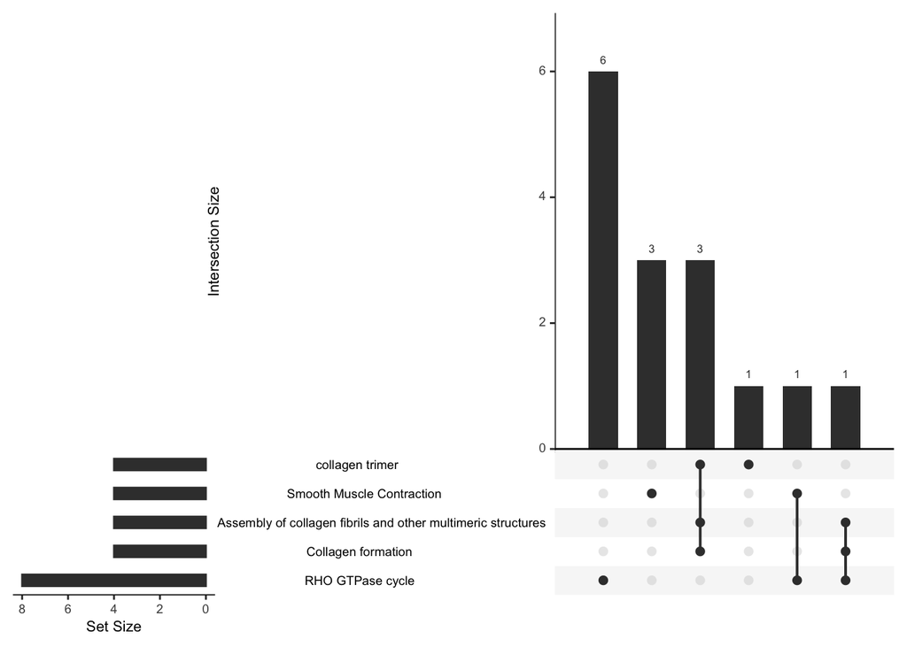

```r
enriched_up <- list.files(path = "./", pattern="*overexpressed*") %>% map_df(~read_tsv(.) %>% mutate(annotation_id = as.character(annotation_id)))
enriched_up_stat_sign <- enriched_up[enriched_up$pval_adj < 0.05, ]
enriched_up_cat_filter <- dplyr::filter(enriched_up_stat_sign, grepl("heart|vessel|tissue|card|pulm", description))

annotation_vs_gene_over <- select(enriched_up_stat_sign, description, genes)
gene_sets_under <- setNames(lapply(strsplit(annotation_vs_gene_over$genes, ","), unique), annotation_vs_gene_over$description)
upset(fromList(gene_sets_under), order.by="freq")
```